# Goodness of Fit Tests

Erin Anderson, Lillian Holden, Amanda Wu, Emily Yang

2023-12-17

# Introduction to Goodness-of-Fit Tests

Before starting to work with a data set, you have to figure out what kind of data it is. Goodness of fit tests report if your data is normal or matches with expected data. Then you are able to pick the best statistical test to run on your data. Different data types have different goodness of fit tests and each test is used to draw different conclusions. Each goodness of fit test has a null and alternate hypothesis and the calculated p-value allows us to reject the null. For a refresher on hypothesis testing see [Module 10](https://fuzzyatelin.github.io/bioanth-stats/module-10/module-10.html).

Previously in the course we learned to use the Chi-squared goodness of fit test in [Module 14](https://fuzzyatelin.github.io/bioanth-stats/module-14/module-14.html#Chi-Square_Tests_of_Goodness_of_Fit_and_Independence). Goodness of fit tests can be used to assess how well Generalized Linear Models fit the data [Module 16](https://fuzzyatelin.github.io/bioanth-stats/module-17/module-17.html).

#### Different Goodness-of-Fit tests we’ll be covering:

- **G Test:** a variation of the chi-squared test and determines if your data matches an expected distribution.
- **Kolmogorov-Smirnov Test:** determines if the observed data matches a normally distributed population.
- **Anderson-Darling Test:** derived from the Kolmogorov-Smirnov test and is more sensitive to the distribution edges.
- **Shapiro-Wilks Test:** determines if a random sample is from a normally distributed population but is used for smaller sample populations under 50.

## Module Objectives

[1] Understand what a goodness of fit test is and how to apply it.

[2] Be able identify which test is most appropriate for your data set.

## Packages

```r
# G test
library(DescTools)
library(curl)
library(tidyverse)
# Anderson Darling test
library(nortest)
```

# G Test

Like the Chi-squared test in [Module 14](https://fuzzyatelin.github.io/bioanth-stats/module-14/module-14.html), the G test allows you to determine if there is a significant difference in proportions of a categorical variable to the theoretical expectation. Chi-squared test give approximately the same results as G test but you can perform more elaborate statistical analyses with G test results. Downside is that less people are familiar with the G test compared to the Chi-squared test. As they give similar results, it’s best to pick one method that is most applicable to your data set rather than using both methods. Pick one and stick with it.

Both G test and Chi-squared Test data needs to fulfill certain assumptions:

1. Random Sample
2. Independence between samples
3. Variable must be proportional or categorical
4. Mutually exclusive categories
5. Variables must have 2 or more options

It’s more beneficial to use the G Test over the Chi-Squared Test if:

1. There are more than 1000 values in total
2. There are outliers in the data
3. If dataset is small use the Fisher’s Exact Test.

**Null Hypothesis:** The observed data has the same proportions as the expected theoretical population.  
**Alternate Hypothesis:** The observed data doesn’t have the same proportions as the expected theoretical population.

## Objectives

[1] Understand when it is appropriate to use the G test.

[2] Be able to run the G test by hand and through an R package.

## G Test Formula

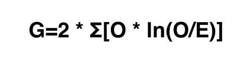

O = Observed  
E = Expected

#### Implementating the G Test on the iris data set

I was out in the field and collected data about 1200 Irises. I noted the color, size, species, and location of each flower. From a glance I see four flower colors that are roughly equally but I want to test statistically there actually is proportionally equal amounts of each flower color.

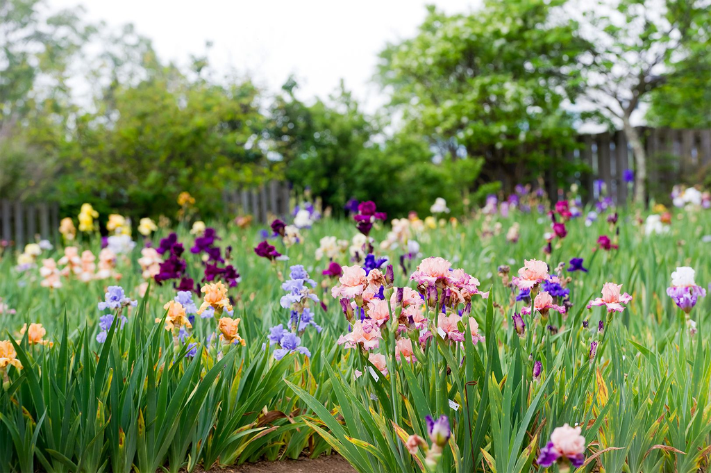

```r
library(curl)
f <- curl("https://raw.githubusercontent.com/YYangEmily/Chisquare-repo/main/Iris.csv")
d <- read.csv(f, header = TRUE, sep = ",", stringsAsFactors = FALSE)
head(d)
```

```
##   X Flower.color Flower.size Flower.species Flower.location
## 1 1       purple       Small       Japanese            West
## 2 2       purple       Large       Japanese           South
## 3 3        white       Large       Siberian            West
## 4 4         blue       Large       Siberian            East
## 5 5       purple       Large       Japanese           South
## 6 6         blue       Large        Bearded            West
```

```r
table(d$Flower.color) # Count how many of each color
```

```
##
##   blue orange purple  white
##    121     59    628    392
```

```r
# Find the G value
G <- 2 * ((121 * log(121/300)) + (59 * log(59/300)) + (628 * log(628/300)) + (392 * log(392/300))) #log function in R is equivalent to ln

G # Use G value to find p-value
```

```
## [1] 725.9525
```

```r
pchisq(725.9525, df=3, lower.tail = FALSE) # Finding the p-value
```

```
## [1] 4.947761e-157
```

We got an G value of 725.95 and the degree of freedom is options-1 = 3. Using those we calculated a p-value of 4.9e-157 which is below the critical p-value = 0.05. We can reject the null hypothesis and conclude that the flower color proportions of the Irises observed are not equally distributed.

```r
library(DescTools)

#perform the G-test
GTest(x = c(121, 59, 628, 392), #observed values
      p = c(1/4, 1/4, 1/4, 1/4)) #expected proportions
```

```
##
##  Log likelihood ratio (G-test) goodness of fit test
##
## data:  c(121, 59, 628, 392)
## G = 725.95, X-squared df = 3, p-value < 2.2e-16
```

Once again, the p-value is below 0.05. We can reject the null hypothesis and conclude that the flower color proportions of the Irises I observed are not equally distributed.

#### Lets do it again with Flower Size

I want to see if the data fits my expectation that there are equal proportions of large and small flowers.

```r
table(d$Flower.size) # Count how many of each size
```

```
##
## Large Small
##   577   623
```

```r
G <- 2 * ((577 * log(577/600)) + (623 * log(623/600)))
G
```

```
## [1] 1.763765
```

```r
pchisq(1.763765, df=1, lower.tail = FALSE) # Finding the p-value
```

```
## [1] 0.1841556
```

```r
GTest(x = c(577, 623), # observed values
      p = c(1/2, 1/2), # expected proportions
      correct = "none") # no correction
```

```
##
##  Log likelihood ratio (G-test) goodness of fit test
##
## data:  c(577, 623)
## G = 1.7638, X-squared df = 1, p-value = 0.1842
```

As you can see this time the p-value = 0.1842 which is above the critical p-value of 0.05 and we fail to reject the null hypothesis. There are equal proportions of each flower size.

## G Test Challenges

Perform the G test with following columns in the iris data set: Flower.location and Flower.species.

Alternate code via Lia Bao

```r
unique(d$Flower.species) # unique elements in the data.
```

```
## [1] "Japanese" "Siberian" "Bearded"  "Dutch"
```

```r
n <- length(unique(d$Flower.species)) #number of elements
n
```

```
## [1] 4
```

```r
fs <- c(as.numeric(table(d$Flower.species))) #extract the numerical data from table
fs
```

```
## [1] 280 297 305 318
```

```r
fp <- c(rep(1/n, each=n)) # set equal proportions repeated
fp
```

```
## [1] 0.25 0.25 0.25 0.25
```

```r
GTest(x=fs,
      p=fp)
```

```
##
##  Log likelihood ratio (G-test) goodness of fit test
##
## data:  fs
## G = 2.536, X-squared df = 3, p-value = 0.4688
```

This tells us that the species of each iris is equally distributed.

## G Test of Independence

In addition to goodness of fit test you can also use the G test for Independence. For example I want to test if flower color and flower size are independent variables.

**Null Hypothesis:** The two test variables are independent.  
**Alternate Hypothesis:** The two variables are dependent.

```r
library(tidyverse)

d %>% group_by(Flower.color, Flower.size) %>%  # Group by independent variables
  dplyr::count(Flower.color, Flower.size) # count how many are in each group
```

```
## # A tibble: 8 × 3
## # Groups:   Flower.color, Flower.size [8]
##   Flower.color Flower.size     n
##   <chr>        <chr>       <int>
## 1 blue         Large          57
## 2 blue         Small          64
## 3 orange       Large          37
## 4 orange       Small          22
## 5 purple       Large         301
## 6 purple       Small         327
## 7 white        Large         182
## 8 white        Small         210
```

```r
obs <- rbind(c(64, 22, 327, 210), # Small flowers
             c(57, 37, 301, 182)) # Large flowers

GTest(obs, # Compare small vs large
      correct = "none") # no correction
```

```
##
##  Log likelihood ratio (G-test) test of independence without correction
##
## data:  obs
## G = 5.5756, X-squared df = 3, p-value = 0.1342
```

We find a p-value of 0.1342 which is above the critical p-value of 0.05 and fail to reject the null hypothesis. We conclude that the two variables are independent.

# Kolmorgorov-Smirnov Test

We can use the **Kolmorgorov-Smirnov Test** as a way to test if our hypothesized results are correct (one-sample) or if two data sets come from the same distribution (two-sample). By using this statistical method, we are aiming to prove that the two data sets we are working with do not come from the same distribution.

The most common way to reject the null is with a student’s t-test, however, this can only be accurately used when we know our data set is **normal**. If we are using data that we aren’t sure about, or know isn’t of a normal distribution, it can be trickier to reject this hypothesis. This test is more effective with larger data sets (n ≥ 50) when compared to the Shapiro-Wilks test which is only effective for smaller data sets.

If we are running a one-sample K-S Test:

1. **Null hypothesis:** The sample comes from the same distribution as the data set we are comparing it with
2. **Alternative hypothesis:** The sample does not come from the same distribution

If we are running a two-sample K-S Test:

1. **Null hypothesis:** Both samples come from the same distribution
2. **Alternative hypothesis:** Both samples do not come from the same distribution

**Why is it important to disprove the null?** Failing to reject a null hypothesis means there is no sufficient evidence for the expected or the observed results we see in our studies.

## Kolmorgorov-Smirnov Test Formula

## Objectives

[1] Understand what a Kolmogorov-Smirnov Test is and how to interpret the results.

[2] Learn what conditions are ideal for a K-S Test.

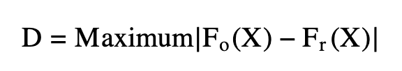

**F<sub>0</sub>(x)** = the total observed frequency distribution of a random sample

**F<sub>0</sub>(x) = <sup>k</sup>⁄<sub>n</sub>** where k = the number of observations and n is the total number of predicted observations

**F<sub>r</sub>(x)** = the theoretical frequency distribution

**D** = the critical value between 0 and 1 indicating the magnitude of the observed difference in distributions. Values closer to 1 indicate high difference, while values closer to 0 indicate high likeness. Unlike a p-value which has a set threshold for whether something is significant or not–although this is also not necessarily the be-all-end-all of significance!–the D value produced from the K-S test is relative to each individual distribution. **Different data sets will produce different D values!**

If the calculated value is **less** than the critical value **D** we must **accept the null hypothesis**

If the calculated value is **greater** than the critical value we can **reject the null hypothesis**

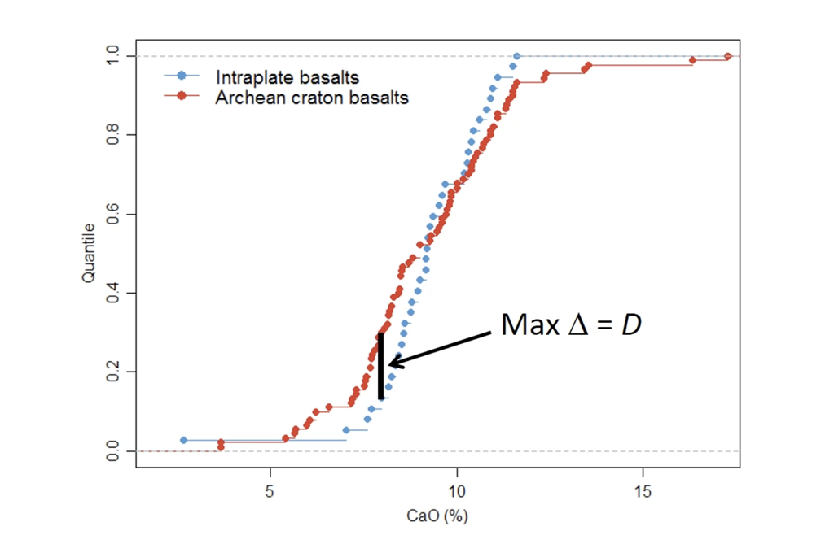

Here we can see that D is showing us the maximum distance between 2 graphs. If the two data sets come from the exact same distribution, our D value (i.e. distance between the graphs) would be small (theoretically 0). If we have data coming from two very distributions our maximum distance between our graphs is large (maximum of 1).

## One-Sample Test

Let’s do an example!

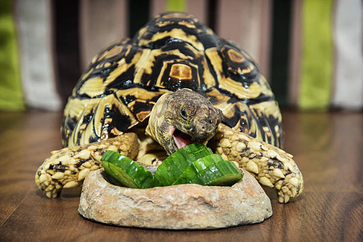

We are zoologists studying turtles and we want to conduct an experiment to see if different species of turtle prefer to eat cucumbers or lettuce when presented with both. We will be including 5 different species and counting how many turtles go for each food choice first in each population (n = 150).

```r
# create matrix with 5 columns and 2 rows
data <- matrix(c(16, 12, 1, 22, 11, 14, 18, 29, 8, 19), nrow = 2, ncol = 5, byrow = TRUE)
# specify the column names and row names of matrix
colnames(data) <- c('A.marmorata ','C.fimbriata ','C.picta ','C.flavomarginata ', 'C.amboinensis')
rownames(data) <-  c('Cucumber','Lettuce')
# assign to table
final = as.table(data)
# display
final
```

```
##          A.marmorata  C.fimbriata  C.picta  C.flavomarginata  C.amboinensis
## Cucumber           16           12        1                22            11
## Lettuce            14           18       29                 8            19
```

**H<sub>0</sub>** = There is no difference among turtle species with respect to their choice of cucumber over lettuce.

**H<sub>1</sub>** = There is a difference among turtle species with respect to their choice of cucumber over lettuce

Let’s say we predict 18 turtles from each species choose cucumber and make a new table with our prediction.

```r
#appending our original table
final_new <- final
#assigning a new row name and filling in the data using the list function
final_new <- rbind(final_new, 'Predictions' = list(18, 18, 18, 18, 18))
#ready to print!
final_new
```

```
##             A.marmorata  C.fimbriata  C.picta  C.flavomarginata  C.amboinensis
## Cucumber    16           12           1        22                11
## Lettuce     14           18           29       8                 19
## Predictions 18           18           18       18                18
```

```r
calculations <- matrix(c(16, 18, '16/150', '18/150', '2/150', 12, 18, '28/150', '36/150', '8/150', 1, 18, '29/150', '54/150', '25/150', 22, 18, '51/150', '72/150', '21/150', 11, 18, '62/150', '90/150', '28/150'), nrow = 5, ncol = 5, byrow = TRUE)
colnames(calculations) <- c('Observed ','Predictions ','F0(X)', 'Fr(X)', '|F0(X) -Fr(X)|')
rownames(calculations) <-  c('A.marmorata ','C.fimbriata ','C.picta ','C.flavomarginata ', 'C.amboinensis')
table = as.table(calculations)
table
```

```
##                   Observed  Predictions  F0(X)  Fr(X)  |F0(X) -Fr(X)|
## A.marmorata       16        18           16/150 18/150 2/150
## C.fimbriata       12        18           28/150 36/150 8/150
## C.picta           1         18           29/150 54/150 25/150
## C.flavomarginata  22        18           51/150 72/150 21/150
## C.amboinensis     11        18           62/150 90/150 28/150
```

Now it’s time to analyze! To find our critical D value we need to look at our table and find the maximum difference between F<sub>0</sub>(x) and F<sub>r</sub>(x). We can see that our maximum value is that of C. amboinensis at 28/150. Our critical D value that we will use to compare our values to is 0.1867. Now we can look at our table and choose a value of alpha to work with. Say we are 5% certain we are going to make a Type 1 error, i.e. detecting a difference under the assumption of the null, we can use our table to choose our critical value.

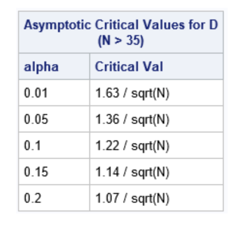

```r
#denote the total number of turtles
n <- 150
#grab our formula
D <- 1.36/sqrt(n)
#calculate!
D
```

```
## [1] 0.1110435
```

Our critical value for our data set at an alpha level of 5% is 0.11, which is smaller than our critical value of 0.1867. Because our value is **greater** than the critical value, we can reject the null and conclude that there is difference among turtle species with their respect to choosing cucumber over lettuce for their snack of choice!

## Kolmorgorov-Smirnov Test Challenge

Assuming an alpha level of 0.01, what is the critical D value for our sample of turtles? Can we still reject the null?

```r
#denote the total number of turtles
n <- 150
#grab our formula
D <- 1.63/sqrt(n)
#calculate!
D
```

```
## [1] 0.1330889
```

YES! 0.133 ≤ 0.1867, therefore we can still reject the null.

Now let’s learn the easy way! Our KS Test is in base R so we can just go ahead and use it as is.

## Two-Sample Test

First, let’s make two data sets, one random, and one normal.

```r
#make this example reproducible
set.seed(0)
#generate two data sets. We are using rpois() to ensure a non-normal distribution, and rnorm() to ensure a normalized one.
data1 <- rpois(n=50, lambda=5)
data2 <- rnorm(100)
```

```r
#using our pre-made function, we are going to fill both arguments with the data sets to ensure a comparison
ks.test(data1, data2)
```

```
##
##  Exact two-sample Kolmogorov-Smirnov test
##
## data:  data1 and data2
## D = 0.95, p-value < 2.2e-16
## alternative hypothesis: two-sided
```

Let’s take a look at this value graphically! To do this we are going to use our data1 and data2 sets we created, and then graph them using an ECDF. An ECDF (Empirical distribution function) creates a cumulative distribution function for our observed data, which we are able to graph together and view the difference in. This code was originally created by Matt Harris (you can check out his site [here](https://rpubs.com/mharris/KSplot))

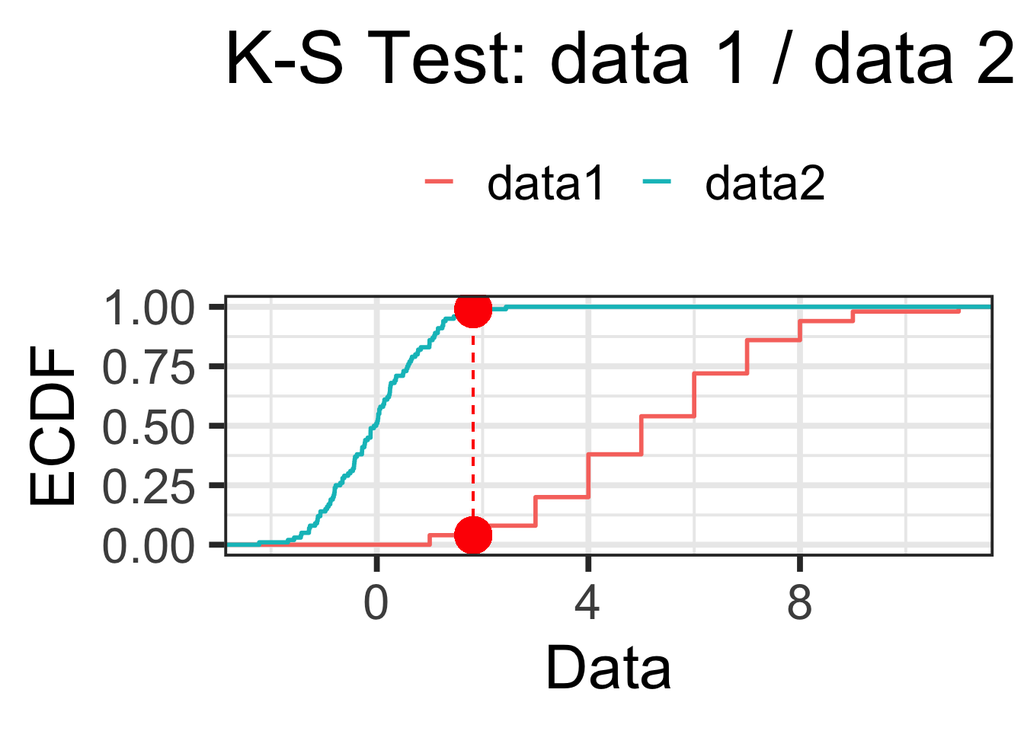

```r
#group both of our data sets into one variable we can call later on.
group <- c(rep("data1", length(data1)), rep("data2", length(data2)))
#create a data frame to work with and call from.
dat <- data.frame(KSD = c(data1,data2), group = group)
# create ECDF of our dats in base are and calling it a memorable variable
ecdf1 <- ecdf(data1)
ecdf2 <- ecdf(data2)
# find minimum and maximum statistics! This will allow us to draw our line between our data sets
minMax <- seq(min(data1, data2), max(data1, data2), length.out=length(data1))
x0 <- minMax[which( abs(ecdf1(minMax) - ecdf2(minMax)) == max(abs(ecdf1(minMax) - ecdf2(minMax))) )]
y0 <- ecdf1(x0) #setting points of reference
y1 <- ecdf2(x0)

# loading in the required package
library(ggplot2)
ggplot(dat, aes(x = KSD, group = group, color = group))+ #calling our df, coloring our lines by groups
  stat_ecdf(size=1) +
    theme_bw(base_size = 30) + #adding a theme
    theme(legend.position ="top") +
    xlab("Data") + #naming our axis
    ylab("ECDF") +
    #geom_line(size=1) +
    geom_segment(aes(x = x0[1], y = y0[1], xend = x0[1], yend = y1[1]),
        linetype = "dashed", color = "red") +
    geom_point(aes(x = x0[1] , y= y0[1]), color="red", size=8) +
    geom_point(aes(x = x0[1] , y= y1[1]), color="red", size=8) +
    ggtitle("K-S Test: data 1 / data 2") + #titling the graph
    theme(legend.title=element_blank())
```

If you’re curious about seeing a KS Test in action, feel free to check out this paper on same-sex sexual behavior in termites.

# Anderson Darling Test

Objectives

- Learn about the Anderson Darling Equation and understand how it can be used in R.
- Go through the Anderson Darling Test step-by-step and how to interpret the results.
- Use the ad.test() built in function with Poisson functions.

## Introduction

The Anderson Darling test is a type of the goodness of fit test used to determine if a sample of data follows a specific kind of distribution, more commonly normal distribution. It is a modification of the Kolmogorov-Smirnov test that focuses more on whether or not the tails follow normal distribution, rather than the peak.

It is important to note that the length of the sample data must be **greater than 7**, but is advised to be **greater than 20**. The smaller the sample of data, the more likely it is to get false results.

Hypotheses

- Null Hypothesis: H0 is the data that follows a specific distribution
- Alternative Hypothesis: HA is the data that does not follow the specific distribution

## Anderson Darling Test Statistic Equation:

The equation below gives you the test statistic for your specified distribution.

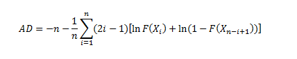

- n = the sample size
- F(Xi) = CDF (cumulative distribution function) for the specified distribution
- i = the ith sample, calculated when the data is sorted in ascending order (1:n)

Once the test statistic is calculated, you can use it to determine whether we can reject the null hypothesis or fail to reject the null. This is done by comparing it to a critical value that is determined by the kind of distribution you are testing for. In this case, we will be testing for normality, so the critical value is **0.787.**

The critical value is published in the following article: Stephens, M. A. (1974). EDF Statistics for Goodness of Fit and Some Comparisons, Journal of the American Statistical Association, 69, pp. 730-737.

If the test statistic is **less then 0.787**, we can fail to reject the null hypothesis, meaning that the data follows normal distribution. If the critical value is **greater than 0.787**, the null hypothesis is rejected and the sample of data does not follow normal distribution.

However, the smaller the sample of data, the more likely you are to get false readings of normality. Therefore, it is best to use the p-value as your indicator in most scenarios or to confirm your results of the test statistic.

You will start by modifying the test statistic using the following equation: **Z = AD(1.0 + 0.75/n + 2.25/n^2).** From here, the p-value can be calculated based on an equation that is determined by the modified test statistic which we will discuss below. Once we calculate the p-value, we can determine whether we can reject the null hypothesis or fail to reject the null.

The test rejects the null hypothesis of normality when the p-value is **less than or equal to the alpha value of 0.05** and accepts the null hypothesis (fails to reject the null) if it is **greater than the alpha value of 0.05.**

### Using the Anderson-Darling Test with Data Known as “chickwts”

Newly hatched chicks were randomly allocated into six groups, and each group was given a different feed supplement. Their weights in grams after six weeks are given along with feed types.

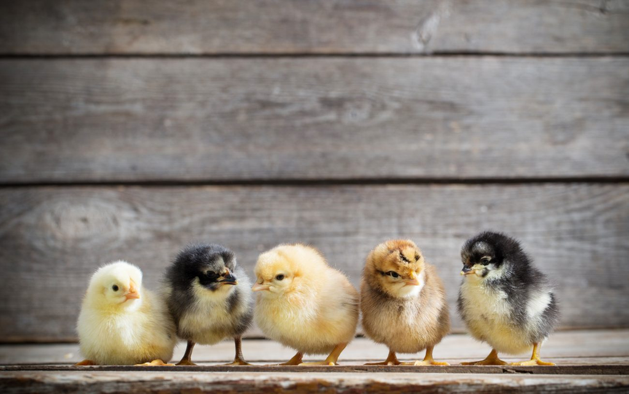

```r
set.seed(1)
d <- chickwts
head(d)
```

```
##   weight      feed
## 1    179 horsebean
## 2    160 horsebean
## 3    136 horsebean
## 4    227 horsebean
## 5    217 horsebean
## 6    168 horsebean
```

#### Determining if the Chick Weight Data follows Normal Distribution

```r
a <- d$weight #assign the weight variable to a vector
a
```

```
##  [1] 179 160 136 227 217 168 108 124 143 140 309 229 181 141 260 203 148 169 213
## [20] 257 244 271 243 230 248 327 329 250 193 271 316 267 199 171 158 248 423 340
## [39] 392 339 341 226 320 295 334 322 297 318 325 257 303 315 380 153 263 242 206
## [58] 344 258 368 390 379 260 404 318 352 359 216 222 283 332
```

#### Calculating the Test Statistic in R Step-By-Step

The several equations below are derived from the formula depicted above and taken from ad.test(), the built in R function we will use later in this module:

```r
x <- sort(a) #a is the data set that you want to test, sort() puts the data in ascending order, which is necessary to compute the anderson darling test statistic
x
```

```
##  [1] 108 124 136 140 141 143 148 153 158 160 168 169 171 179 181 193 199 203 206
## [20] 213 216 217 222 226 227 229 230 242 243 244 248 248 250 257 257 258 260 260
## [39] 263 267 271 271 283 295 297 303 309 315 316 318 318 320 322 325 327 329 332
## [58] 334 339 340 341 344 352 359 368 379 380 390 392 404 423
```

```r
n <- length(x) #determine the length of the sample of data
n #n is 71
```

```
## [1] 71
```

#### Calculating the Cumulative Distribution F(Xi)

```r
logp1 <- pnorm((x - mean(x))/sd(x), log.p = TRUE) #F(Xi) is the cumulative distribution and pnorm() allows us to calculate the cumulative probability for each data point using the mean and standard deviation, which are used to define normal distribution, log.p() gives each of these probabilities as a log()
logp1
```

```
##  [1] -3.69751578 -3.23621401 -2.91425020 -2.81145133 -2.78610263 -2.73582529
##  [7] -2.61257413 -2.49279405 -2.37646196 -2.33088919 -2.15404421 -2.13254785
## [13] -2.08995895 -1.92495515 -1.88503299 -1.65651337 -1.54924135 -1.48027517
## [19] -1.42987556 -1.31664473 -1.26996936 -1.25465553 -1.17990637 -1.12227085
## [25] -1.10815964 -1.08029194 -1.06653474 -0.91049018 -0.89822839 -0.88607892
## [31] -0.83859602 -0.83859602 -0.81551781 -0.73816842 -0.73816842 -0.72754756
## [37] -0.70662323 -0.70662323 -0.67602336 -0.63667261 -0.59895033 -0.59895033
## [43] -0.49524221 -0.40503449 -0.39124772 -0.35193782 -0.31560764 -0.28213146
## [49] -0.27682060 -0.26642363 -0.26642363 -0.25632230 -0.24651179 -0.23233062
## [55] -0.22322578 -0.21439463 -0.20165026 -0.19348172 -0.17417117 -0.17049452
## [61] -0.16687823 -0.15638537 -0.13090592 -0.11140167 -0.08980016 -0.06811938
## [67] -0.06638164 -0.05091853 -0.04821581 -0.03438676 -0.01936601
```

#### Calculating -F(Xn-i+1)

```r
logp2 <- pnorm(-(x - mean(x))/sd(x), log.p = TRUE) #using pnorm() to find -F(Xn-i+1) for each data point
logp2
```

```
##  [1] -0.02509734 -0.04010605 -0.05577140 -0.06200060 -0.06364405 -0.06703815
##  [7] -0.07617449 -0.08629742 -0.09747900 -0.10226450 -0.12331408 -0.12616987
## [13] -0.13203789 -0.15768627 -0.16466718 -0.21171298 -0.23877643 -0.25822044
## [19] -0.27356710 -0.31202001 -0.32967173 -0.33571621 -0.36716912 -0.39384247
## [25] -0.40072540 -0.41475270 -0.42189818 -0.51471143 -0.52305102 -0.53148614
## [31] -0.56619222 -0.56619222 -0.58413168 -0.65006583 -0.65006583 -0.65989093
## [37] -0.67985032 -0.67985032 -0.71056934 -0.75300304 -0.79714864 -0.79714864
## [43] -0.94013087 -1.09947409 -1.12766823 -1.21511414 -1.30691239 -1.40313347
## [49] -1.41960507 -1.45292366 -1.45292366 -1.48674473 -1.52107064 -1.57351109
## [55] -1.60910906 -1.64521975 -1.70035188 -1.73775378 -1.83353865 -1.85308852
## [61] -1.87276993 -1.93260586 -2.09801545 -2.24979674 -2.45473259 -2.72035988
## [67] -2.74534199 -3.00287964 -3.05607935 -3.38722770 -3.95390325
```

#### Calculating the Summation Portion of the Equation

```r
h <- (2 * seq(1:n) - 1) * (logp1 + rev(logp2)) #summation part of the equation, rev() computes the function described in logp2 of each point of data in descending order, rather than ascending
```

#### Calculating the Test Statistic

```r
A <- -n - mean(h) #computing the test statistic by combining the first half of the equation with the second half
A # The test statistic is computed
```

```
## [1] 0.4648545
```

The test statistic is less than the critical value of 0.787 meaning we can fail to reject the null - meaning the sample of data follows normal distribution. Because the sample of data is on the smaller side, 71, we can use the p-value to confirm our results.

#### Calculating the Modified Test Statistic

```r
# Z = AD(1.0 + 0.75/n + 2.25/n^2)
AA <- (1 + 0.75/n + 2.25/n^2) * A
AA #The modified test statistic is computed
```

```
## [1] 0.4699724
```

#### P Value Equations are Dependent Upon the Modified Test Statistic Value

The following formulas are taken from Agostino and Stephen’s Goodness of Fit Techniques:

- Use this if AA > 10  
  pval <- 3.7e-24
- Use this if AA < 0.2  
  pval <- 1 - exp(-13.436 + 101.14 * AA - 223.73 * AA^2)
- Use this if AA < 0.34  
  pval <- 1 - exp(-8.318 + 42.796 * AA - 59.938 * AA^2)
- Use this if AA < 0.6  
  pval <- exp(0.9177 - 4.279 * AA - 1.38 * AA^2)
- Use this if AA < 10  
  pval <- exp(1.2937 - 5.709 * AA + 0.0186 * AA^2)

#### Calculating the p-value

```r
pval <- exp(0.9177 - 4.279 * AA - 1.38 * AA^2)
pval #The p-value is computed
```

```
## [1] 0.2470614
```

It can be concluded that chick weight data does follow normal distribution because the p-value is greater than 0.05.

### Challenge 1

Determine the test statistic (A), modified test statistic (AA), and p-value of a sample of the chickwts data set. Is this sample of the data set originating from normal distribution? How do you know this?

```r
set.seed(1)
b <- sample(a, size=71, replace=TRUE, prob=NULL) #I chose 71 because that is the length of the initial data set
b
```

```
##  [1] 216 392 179 171 320 141 258 303 244 153 108 423 423 171 295 199 158 283 226
## [20] 340 257 250 257 295 283 339 295 248 283 392 303 226 168 230 267 141 160 334
## [39] 169 271 318 283 283 181 339 318 243 193 181 271 250 318 199 334 244 316 148
## [58] 318 404 368 303 171 140 179 320 258 327 260 344 193 230
```

#### Calculate the Test Statistic (A)

```r
x <- sort(b)
n <- length(x)
logp1 <- pnorm((x - mean(x))/sd(x), log.p = TRUE)
logp2 <- pnorm(-(x - mean(x))/sd(x), log.p = TRUE)
h <- (2 * seq(1:n) - 1) * (logp1 + rev(logp2))
A <- -n - mean(h)
A
```

```
## [1] 0.5180958
```

The test statistic is less than the critical value of 0.787 meaning we can fail to reject the null - meaning the sample of data follows normal distribution. Let’s confirm this with our p-value!

#### Calculate the Modified Test Statistic (AA)

```r
AA <- (1 + 0.75/n + 2.25/n^2) * A
AA
```

```
## [1] 0.5237999
```

#### Calculating the p-value with the equation based on the modified test statistic (AA)

```r
pval <- exp(0.9177 - 4.279 * AA - 1.38 * AA^2)
pval
```

```
## [1] 0.1822702
```

The p-value is greater than 0.05, so the test fails to reject the null hypothesis meaning the sample of chick weight data follows normal distribution.

#### Performing the Anderson Darling Test on the Sample of Data using the ad.test() built in function

```r
library(nortest) #make sure your package is loaded
```

#### Creating a function that is normally distributed

```r
set.seed(1) #Use the set.seed() function to allow the data to repeatable
ndistribution <- rnorm(100, 5, 1) #The rnorm() function generates a random sample that is normally distributed
ndistribution
```

```
##   [1] 4.373546 5.183643 4.164371 6.595281 5.329508 4.179532 5.487429 5.738325
##   [9] 5.575781 4.694612 6.511781 5.389843 4.378759 2.785300 6.124931 4.955066
##  [17] 4.983810 5.943836 5.821221 5.593901 5.918977 5.782136 5.074565 3.010648
##  [25] 5.619826 4.943871 4.844204 3.529248 4.521850 5.417942 6.358680 4.897212
##  [33] 5.387672 4.946195 3.622940 4.585005 4.605710 4.940687 6.100025 5.763176
##  [41] 4.835476 4.746638 5.696963 5.556663 4.311244 4.292505 5.364582 5.768533
##  [49] 4.887654 5.881108 5.398106 4.387974 5.341120 3.870637 6.433024 6.980400
##  [57] 4.632779 3.955865 5.569720 4.864945 7.401618 4.960760 5.689739 5.028002
##  [65] 4.256727 5.188792 3.195041 6.465555 5.153253 7.172612 5.475510 4.290054
##  [73] 5.610726 4.065902 3.746367 5.291446 4.556708 5.001105 5.074341 4.410479
##  [81] 4.431331 4.864821 6.178087 3.476433 5.593946 5.332950 6.063100 4.695816
##  [89] 5.370019 5.267099 4.457480 6.207868 6.160403 5.700214 6.586833 5.558486
##  [97] 3.723408 4.426735 3.775387 4.526599
```

#### Using the ad.test() function

```r
ad.test(ndistribution) #that was easy!
```

```
##
##  Anderson-Darling normality test
##
## data:  ndistribution
## A = 0.16021, p-value = 0.9471
```

Because the p-value is greater than 0.05 and the test statistic is less than the critical value of 0.787, it can be determined that the data follows normal distribution and that the null hypothesis has failed being rejected.

#### Visualizing Results

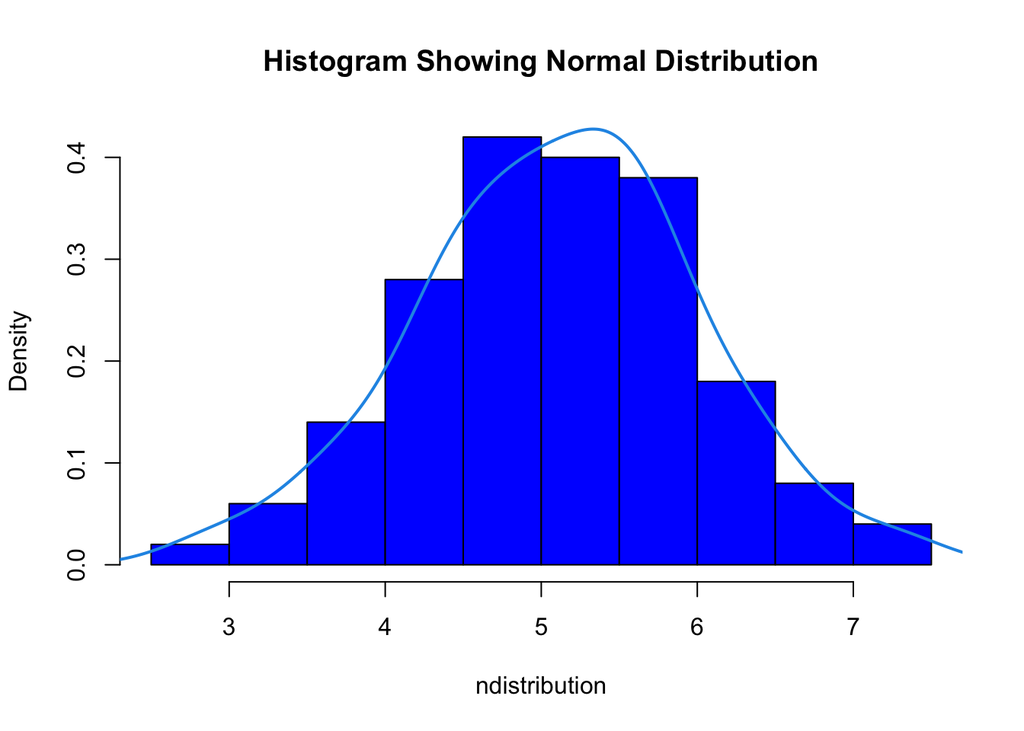

```r
hist(ndistribution, main = "Histogram Showing Normal Distribution", prob = TRUE, col="blue")
lines(density(ndistribution), col = 4, lwd = 2)
```

### Challenge 2

Create a data set using a poisson function that is not normally distributed. Use the ad.test() to confirm that the data is not normally distributed. Plot the data using a histogram to visualize your results.

```r
set.seed(1)
nodistribution <- rpois(100, 5) #rpois() can be used to create a sample that is not normally distributed
nodistribution
```

```
##   [1]  4  4  5  8  3  8  9  6  6  2  3  3  6  4  7  5  6 11  4  7  9  3  6  3  4
##  [26]  4  1  4  8  4  5  5  5  3  7  6  7  2  6  4  7  6  7  5  5  7  1  5  6  6
##  [51]  5  7  4  3  2  2  4  5  6  4  8  4  5  4  6  3  5  7  2  8  4  7  4  4  5
##  [76]  8  7  4  7  9  4  6  4  4  6  3  6  2  3  3  3  2  6  8  7  7  5  4  7  5
```

#### Using the ad.test() function

```r
ad.test(nodistribution)
```

```
##
##  Anderson-Darling normality test
##
## data:  nodistribution
## A = 1.3077, p-value = 0.002035
```

Because the p-value is less than or equal to 0.05 and the test statistic is greater than the critical value of 0.787, it can be determined that the data is different than normal and the null hypothesis is rejected.

#### Visualizing Results

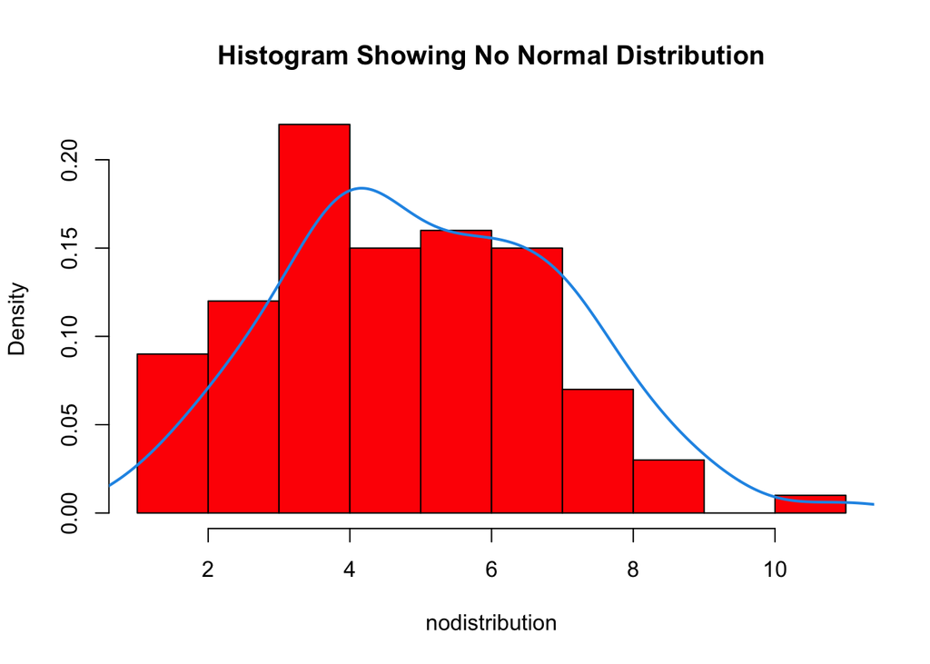

```r
hist(nodistribution, main= "Histogram Showing No Normal Distribution", prob = TRUE, col="red")
lines(density(nodistribution), col = 4, lwd = 2)
```

### Shortcut to Creating Poisson Data Sets and Using the ad.test() function all at once

```r
ad.test(rnorm(100, mean = 5, sd = 3))
```

```
##
##  Anderson-Darling normality test
##
## data:  rnorm(100, mean = 5, sd = 3)
## A = 0.61673, p-value = 0.1057
```

The data set follows normal distribution because the p-value >0.05 and the test statistic is less than the critical value of 0.787.

```r
ad.test(rpois(100,5))
```

```
##
##  Anderson-Darling normality test
##
## data:  rpois(100, 5)
## A = 2.7062, p-value = 7.252e-07
```

The data set does not follow normal distribution because the p-value <0.05 and the test statistic is greater than the critical value of 0.787.

# Shapiro-Wilk Test

*Objectives:*

[1] Learn the Shapiro-Wilk Function and how it is derived.

[2] Use the shapiro.test() function in R and interpret the results.

Like the other Goodness of Fit tests, the **Shapiro-Wilk test** is a test of normality that is used to determine whether a sample came from a normal distribution. The S-W test compares the actual SD of data to the computed SD from the slope of a QQ plot for the data and looks at its ratio. If the data are sampled from a normal distribution, the values should be really similar and the ratio will be close to 1.0.

- **Null hypothesis:** the sample follows a normal distribution (p > 0.5); we have failed to reject the null
- **Alt hypothesis:** the sample does not follow a normal distribution (p < 0.5); the null hypothesis is rejected

## Why should you use the Shapiro-Wilk test?

- Used on one sample with univariate, continuous data
- More appropriate method for smaller samples (n<50)
  - May be better for wildlife samples that are typically smaller
- More powerful than the Anderson-Darling test

## Cautions when using the Shapiro-Wilk test

- The test does not work on larger samples because the test becomes more sensitive to small deviations which leads to the greater probability of rejecting the null hypothesis
- You shouldn’t use the Shapiro-Wilk test when evaluating assumptions for parametric tests (i.e. ANOVA, T tests) because it’s too sensitive
- Not ideal if several values within the data are identical

The denominator is essentially the sum of squares equation which calculates variances while the numerator is the estimate slope of the Q-Q plot. The a values are constants generated from the means, variances and co-variances of the order statistics of a sample size (n) from a normal distribution. Ideally, the slope of the Q-Q plot should be equal to the standard deviation if it is normally distributed so if you were to square this value, then it should equal to variance.

- If the null hypothesis is true, then the W statistic should be variance over variance (both values are the same) which should equal to one.
- If the W statistic is less than one, then there is a difference between the data and its normal distribution
  - The p value will determine whether the W statistic is significant

## Calculating the W statistic

In order to calculate the W statistic, here is the following procedure:

- First, the sample size of n has to be sorted in increasing order and the resulting sorted sample is designated as y1, y2, ..yn
- Then, you calculate the sum of squares using this formula:

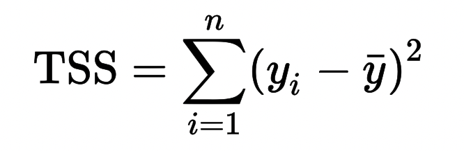

- To calculate the numerator, if the sample size is an even number, then it is calculated using k = n/2
  - If the sample size is odd, the median must not be included so it’s calculated as k = (n-1)/2 using this formula:

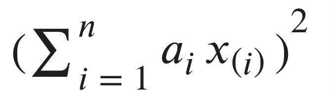

- The test statistic is finally calculated as W = b^2 / (n-1)*S^2
  - You analyze the value by using the critical threshold table:

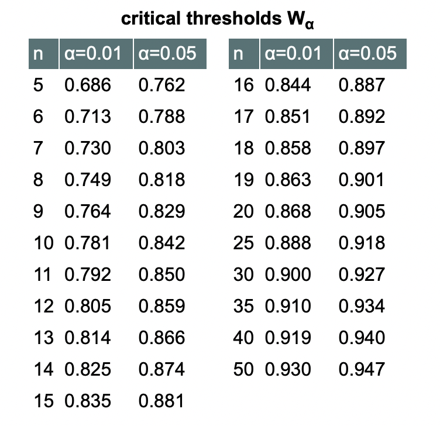

**If the test statistic is smaller than the critical threshold then the assumption of a normal distribution is rejected.**

### Conducting a Shapiro-Wilk Test

Let’s go through with a very small list of values to see how the W statistic can be calculated. We will work to a 95% degree of confidence (0.05).

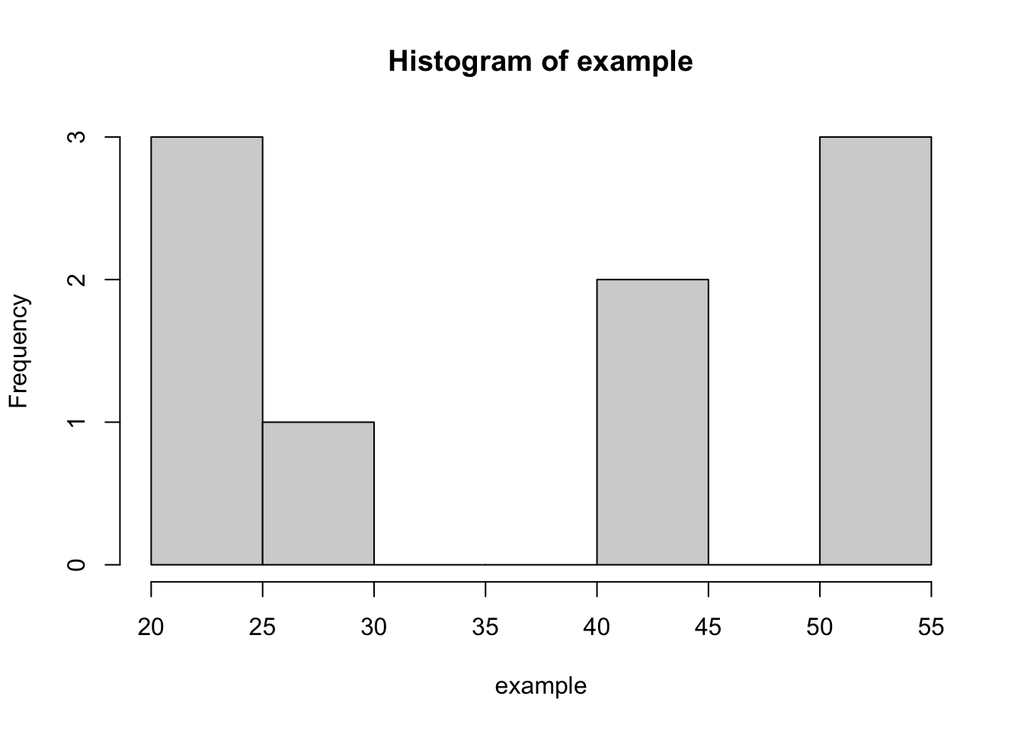

```r
example <- c(20, 20, 21, 26, 43, 43, 54, 54, 55) # list of numbers in chronological order

hist(example) # looking at the data
```

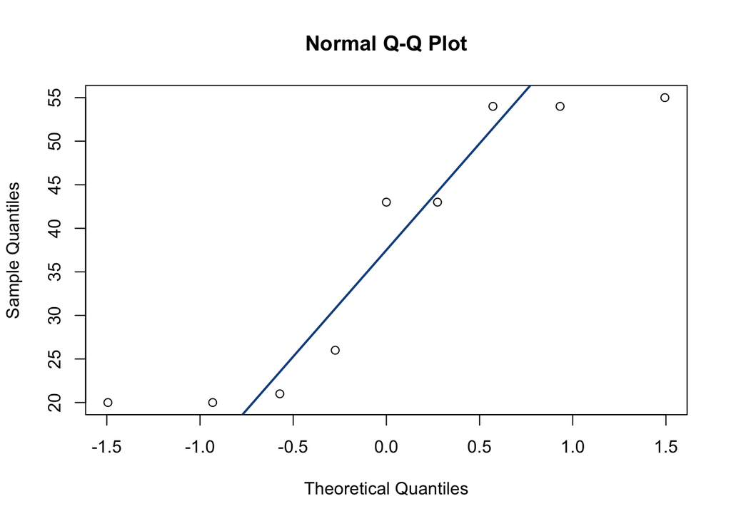

```r
qqnorm(example)
qqline(example, col = "dodgerblue4", lwd = 2)
```

```r
# using coefficients for n=9 to calculate the numerator
0.5888*(55-20) + 0.3244*(54-20) + 0.1976*(54-21) + 0.0947*(43-26)
```

```
## [1] 39.7683
```

```r
# calculating the standard deviation
sd(example)
```

```
## [1] 15.52417
```

```r
# calculating the W statistic
((39.7683)^2) / ((9-1)*15.52^2)
```

```
## [1] 0.8207306
```

Our calculated value of 0.8207 is less than the critical threshold for n=9 (0.829) which means that our data is not normally distributed.

As you can see, the Shapiro-Wilk Test can be really difficult to calculate, especially if you have more values, so there’s a simple command in R to conduct this test!

```r
shapiro.test(example)
```

```
##
##  Shapiro-Wilk normality test
##
## data:  example
## W = 0.82098, p-value = 0.03535
```

Although the W statistic is pretty close to 1, it is under the critical threshold and the p-value is under 0.05 which reinforces the idea that this data is not normally distributed.

#### Now, let’s look at another data set where it may be of normal distribution.

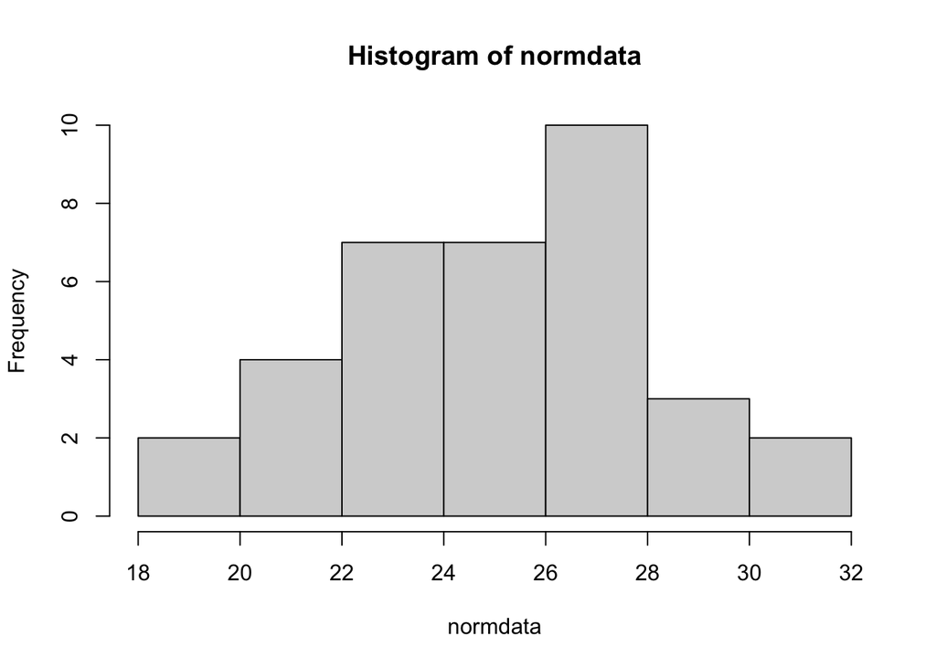

```r
library(ggpubr)
library(dplyr)
set.seed(123)
normdata <- rnorm(35, mean = 25, sd = 3) # making a normally distributed graph
hist(normdata)
```

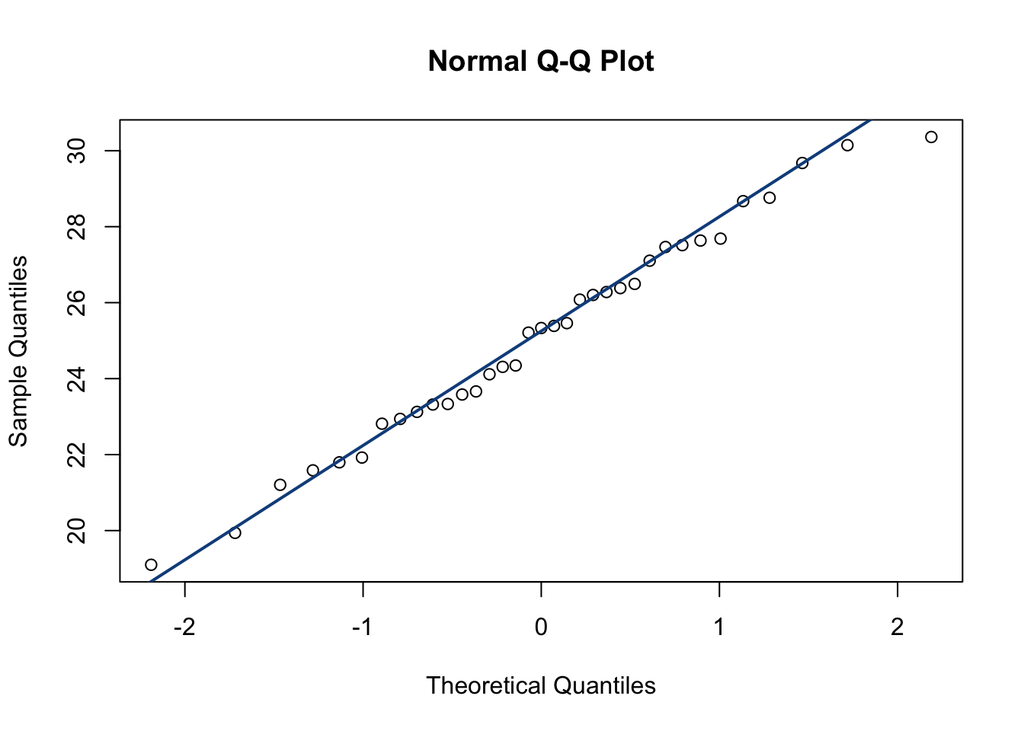

```r
qqnorm(normdata)
qqline(normdata, col = "dodgerblue4", lwd = 2)
```

As we can see, the data set we created follows the guidelines of being normally distributed data but let’s see how to test its normality with the Shapiro-Wilk test.

1. **Null hypothesis:** the data follows a normal distribution
2. **Alt hypothesis:** the data does not follow a normal distribution

```r
shapiro.test(normdata)
```

```
##
##  Shapiro-Wilk normality test
##
## data:  normdata
## W = 0.98495, p-value = 0.9027
```

Here, the W statistic is really close to 1 and the p-value is greater than 0.05 so the null hypothesis is not rejected.

## Shapiro-Wilk Challenge

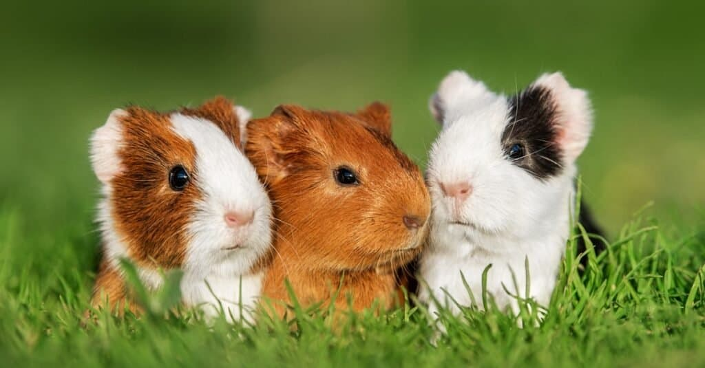

ToothGrowth is a data set in R showing the length of teeth of guinea pigs at three Vitamin C dosage levels(0.5, 1 and 2mg) with two delivery methods(orange juice or ascorbic acid). The column ‘len’ shows the tooth length. Test the normality of the distribution of these guinea pigs’ teeth lengths.

```r
data("ToothGrowth")
head(ToothGrowth)
```

```
##    len supp dose
## 1  4.2   VC  0.5
## 2 11.5   VC  0.5
## 3  7.3   VC  0.5
## 4  5.8   VC  0.5
## 5  6.4   VC  0.5
## 6 10.0   VC  0.5
```

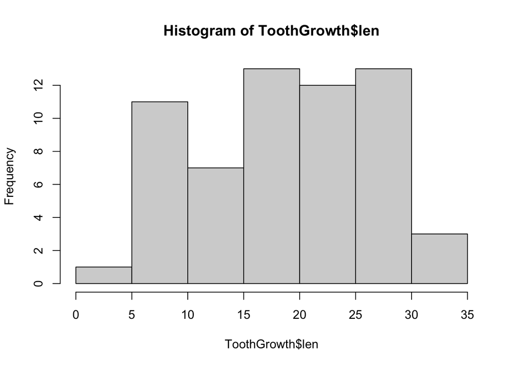

```r
hist(ToothGrowth$len)
```

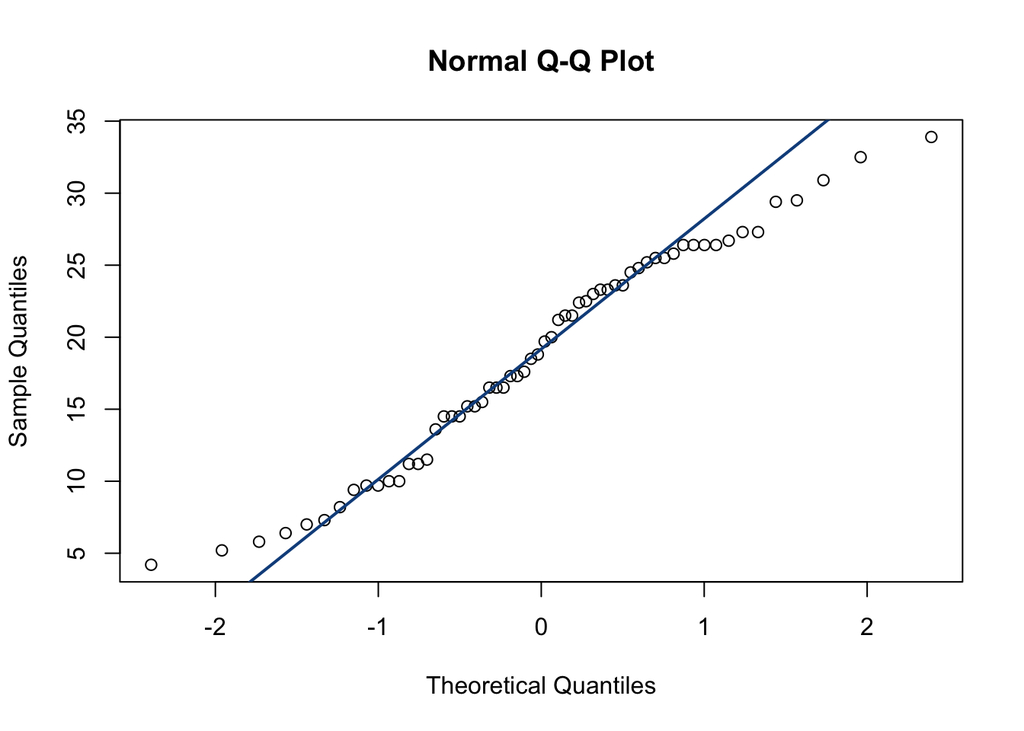

```r
qqnorm(ToothGrowth$len)
qqline(ToothGrowth$len, col = "dodgerblue4", lwd = 2) #looks fairly normal but might have some difference
```

```r
shapiro.test(ToothGrowth$len)
```

```
##
##  Shapiro-Wilk normality test
##
## data:  ToothGrowth$len
## W = 0.96743, p-value = 0.1091
```

# Final Challenge

```r
goodness_of_fit <- c(4.942893, 5.503608, 6.085769, 4.309046, 3.715401, 5.046726, 4.764293, 4.457112, 4.566690, 4.350528, 5.726751, 6.151912, 5.992160, 4.570487, 6.238304, 4.720654, 6.757903, 5.560746, 4.547216, 4.167957, 3.833429, 3.934409, 3.436218, 6.156537, 5.832047, 4.772671, 5.266137, 4.623297, 7.441365, 4.204661, 4.945123)
goodness_of_fit
```

```
##  [1] 4.942893 5.503608 6.085769 4.309046 3.715401 5.046726 4.764293 4.457112
##  [9] 4.566690 4.350528 5.726751 6.151912 5.992160 4.570487 6.238304 4.720654
## [17] 6.757903 5.560746 4.547216 4.167957 3.833429 3.934409 3.436218 6.156537
## [25] 5.832047 4.772671 5.266137 4.623297 7.441365 4.204661 4.945123
```

For the following challenge, you will be using the “goodness_of_fit” data set that was created above. Determine which type of Goodness of Fit Tests we have described above would be best to use to test for normality. Compare these tests along with one other test that may not work as well.

First, we need to determine how many data points there are. You can count them by hand or use the length() function:

```r
length(goodness_of_fit)
```

```
## [1] 31
```

- We can rule out using the G-test as it is best used for categorical data.
- We can rule out the Kolmorgorov-Smirnov Test because as described, we must use that for data sets that are greater than 50 points.

The two tests that remain that are able to be used with data sets below 50 are the Anderson Darling test and the Shapiro-Wilk Test. Let’s compare their results using the built in R functions!

```r
ad.test(goodness_of_fit)
```

```
##
##  Anderson-Darling normality test
##
## data:  goodness_of_fit
## A = 0.43394, p-value = 0.283
```

```r
shapiro.test(goodness_of_fit)
```

```
##
##  Shapiro-Wilk normality test
##
## data:  goodness_of_fit
## W = 0.9651, p-value = 0.3952
```

The p-value for each test is greater than 0.05 meaning that we can fail to reject the null hypothesis and that the data set does indeed follow normal distribution. This makes sense because it was created using the rnorm() function! Although both tests show that the data set follows normal distribution, the Shapiro Wilk test is more powerful than the Anderson Darling test and would be more accurate in this scenario.

Now, let’s compare it with the Kolmorgorov-Smirnov Test:

```r
ks.test(goodness_of_fit, "rnorm")
```

```
##
##  Exact one-sample Kolmogorov-Smirnov test
##
## data:  goodness_of_fit
## D = 2.2584, p-value = 3.331e-16
## alternative hypothesis: two-sided
```

## Sources

G test

https://www.statology.org/g-test/  
https://www.statstest.com/g-test/  
https://www.biostathandbook.com/gtestgof.html  
https://www.biostathandbook.com/gtestind.html  
https://www.r-bloggers.com/2022/05/calculate-the-p-value-from-chi-square-statistic-in-r/  
https://stats.libretexts.org/Bookshelves/Applied_Statistics/Biological_Statistics_(McDonald)/02%3A_Tests_for_Nominal_Variables/2.04%3A_GTest_of_Goodness-of-Fit

Kolmogorov-Smirnov

https://www.tutorialspoint.com/statistics/kolmogorov_smirnov_test.htm  
https://towardsdatascience.com/understanding-kolmogorov-smirnov-ks-tests-for-data-drift-on-profiled-data-5c8317796f78  
https://www.itl.nist.gov/div898/handbook/eda/section3/eda35g.htm  
https://www.researchgate.net/post/Interpret_P_and_D_values_in_Two-Sample_Kolmogorov-Smirnov_Test  
https://www.statisticshowto.com/kolmogorov-smirnov-test/  
https://blogs.sas.com/content/iml/2019/05/15/kolmogorov-d-statistic.html  
https://www.sciencedirect.com/topics/earth-and-planetary-sciences/kolmogorov-smirnov-test  
https://stat.ethz.ch/R-manual/R-devel/library/stats/html/ks.test.html  
https://www.statology.org/kolmogorov-smirnov-test-r/

Anderson Darling

https://www.itl.nist.gov/div898/handbook/eda/section3/eda35e.htm  
https://www.statology.org/anderson-darling-test-r/  
https://variation.com/wp-content/distribution_analyzer_help/hs140.htm  
https://www.rdocumentation.org/packages/datasets/versions/3.6.2/topics/chickwts  
https://citeseerx.ist.psu.edu/document?repid=rep1&type=pdf&doi=d973dfd21d5c3ee5b5860191ee0de9635111dda1  
https://search.r-project.org/CRAN/refmans/nortest/html/ad.test.html  
https://www.statisticshowto.com/anderson-darling-test/  
https://welcometochickenlandia.com/blog/the-age-old-practice-of-cold-brooding-baby-chicks/  
https://www.jstor.org/stable/pdf/2286009.pdf?refreqid=fastly-default%3A97956dda812cf4fdf7108dba8f38485c&ab_segments=&origin=&initiator=&acceptTC=1

Shapiro-Wilk

http://www.statistics4u.info/fundstat_eng/ee_shapiro_wilk_test.html#  
http://blog.excelmasterseries.com/2015/05/how-to-create-completely-automated_4.html  
https://www.graphpad.com/guides/prism/latest/statistics/stat_choosing_a_normality_test.htm  
https://www.sciencedirect.com/topics/mathematics/wilk-test  
http://collbiom.up.lublin.pl/pdf/cb41_211.pdf